# Lab 7: RNA Seq Workflow - Gene-level exploratory analysis and differential expression

## Reading in data with tximeta

### Load airway data package

```r
library("airway")
```

### Determine where files have been installed

```r
dir <- system.file("extdata", package="airway", mustWork=TRUE)
```

### List files in the directory

```r
list.files(dir)
```

```
##  [1] "GSE52778_series_matrix.txt"        "Homo_sapiens.GRCh37.75_subset.gtf"
##  [3] "quants"                            "sample_table.csv"
##  [5] "SraRunInfo_SRP033351.csv"          "SRR1039508_subset.bam"
##  [7] "SRR1039509_subset.bam"             "SRR1039512_subset.bam"
##  [9] "SRR1039513_subset.bam"             "SRR1039516_subset.bam"
## [11] "SRR1039517_subset.bam"             "SRR1039520_subset.bam"
## [13] "SRR1039521_subset.bam"
```

```r
list.files(file.path(dir, "quants"))
```

```
## [1] "SRR1039508" "SRR1039509"
```

### Load sample_table.csv file containing detailed sample information

```r
csvfile <- file.path(dir, "sample_table.csv")
coldata <- read.csv(csvfile, row.names=1, stringsAsFactors=FALSE)
coldata
```

```
##            SampleName    cell   dex albut        Run avgLength Experiment
## SRR1039508 GSM1275862  N61311 untrt untrt SRR1039508       126  SRX384345
## SRR1039509 GSM1275863  N61311   trt untrt SRR1039509       126  SRX384346
## SRR1039512 GSM1275866 N052611 untrt untrt SRR1039512       126  SRX384349
## SRR1039513 GSM1275867 N052611   trt untrt SRR1039513        87  SRX384350
## SRR1039516 GSM1275870 N080611 untrt untrt SRR1039516       120  SRX384353
## SRR1039517 GSM1275871 N080611   trt untrt SRR1039517       126  SRX384354
## SRR1039520 GSM1275874 N061011 untrt untrt SRR1039520       101  SRX384357
## SRR1039521 GSM1275875 N061011   trt untrt SRR1039521        98  SRX384358
##               Sample    BioSample
## SRR1039508 SRS508568 SAMN02422669
## SRR1039509 SRS508567 SAMN02422675
## SRR1039512 SRS508571 SAMN02422678
## SRR1039513 SRS508572 SAMN02422670
## SRR1039516 SRS508575 SAMN02422682
## SRR1039517 SRS508576 SAMN02422673
## SRR1039520 SRS508579 SAMN02422683
## SRR1039521 SRS508580 SAMN02422677
```

### Select first 2 samples in dataset

```r
coldata <- coldata[1:2,]
coldata$names <- coldata$Run
coldata$files <- file.path(dir, "quants", coldata$names, "quant.sf.gz")
file.exists(coldata$files)
```

```
## [1] TRUE TRUE
```

### Load tximeta package and run its main function

```r
library("tximeta")
se <- tximeta(coldata)
```

```
## importing quantifications
```

```
## reading in files with read_tsv
```

[output not shown]

### Determine dimensions of the se object

```r
dim(se)
```

```
## [1] 205870      2
```

```r
head(rownames(se))
```

```
## [1] "ENST00000456328.2" "ENST00000450305.2" "ENST00000488147.1"
## [4] "ENST00000619216.1" "ENST00000473358.1" "ENST00000469289.1"
```

### Summarize transcript-level quantifications

```r
gse <- summarizeToGene(se)
```

```
## loading existing TxDb created: 2020-10-18 11:51:51
```

```
## obtaining transcript-to-gene mapping from TxDb
```

```
## generating gene ranges
```

```
## summarizing abundance
```

```
## summarizing counts
```

```
## summarizing length
```

### Check that dimensions are reduced and row IDs are gene IDs

```r
dim(gse)
```

```
## [1] 58294     2
```

```r
head(rownames(gse))
```

```
## [1] "ENSG00000000003.14" "ENSG00000000005.5"  "ENSG00000000419.12"
## [4] "ENSG00000000457.13" "ENSG00000000460.16" "ENSG00000000938.12"
```

## Summarized Experiment

### Components of a SummarizedExperiment object

The assay (pink block) contains the matrix of counts, the rowRanges (blue block) contains information about the genomic ranges and the colData (green block) contains information about the samples. The highlighted line in each block represents the first row (note that the first row of colData lines up with the first column of the assay).

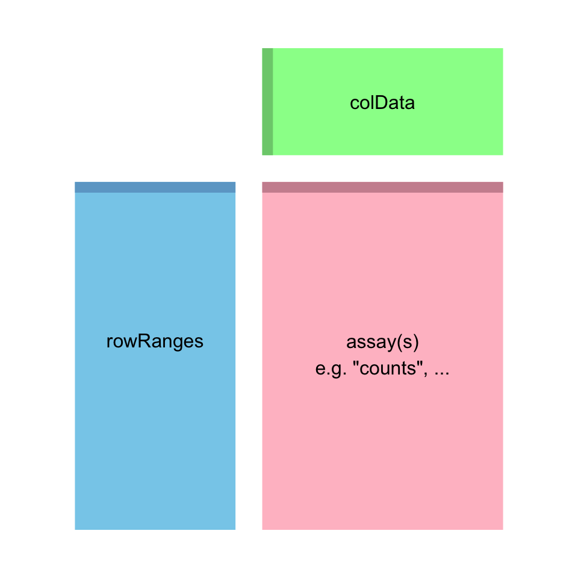

```r
data(gse)
gse
```

```
## class: RangedSummarizedExperiment
## dim: 58294 8
## metadata(6): tximetaInfo quantInfo ... txomeInfo txdbInfo
## assays(3): counts abundance length
## rownames(58294): ENSG00000000003.14 ENSG00000000005.5 ...
##   ENSG00000285993.1 ENSG00000285994.1
## rowData names(1): gene_id
## colnames(8): SRR1039508 SRR1039509 ... SRR1039520 SRR1039521
## colData names(3): names donor condition
```

### Examine assay names with the function assayNames()

### Examine counts using the function assay() [Note: counts is the first matrix]

```r
assayNames(gse)
```

```
## [1] "counts"    "abundance" "length"
```

```r
head(assay(gse), 3)
```

```
##                    SRR1039508 SRR1039509 SRR1039512 SRR1039513 SRR1039516
## ENSG00000000003.14    708.164    467.962    900.992    424.368   1188.295
## ENSG00000000005.5       0.000      0.000      0.000      0.000      0.000
## ENSG00000000419.12    455.000    510.000    604.000    352.000    583.000
##                    SRR1039517 SRR1039520 SRR1039521
## ENSG00000000003.14   1090.668    805.929    599.337
## ENSG00000000005.5       0.000      0.000      0.000
## ENSG00000000419.12    773.999    409.999    499.000
```

```r
colSums(assay(gse))
```

```
## SRR1039508 SRR1039509 SRR1039512 SRR1039513 SRR1039516 SRR1039517 SRR1039520
##   21100805   19298584   26145537   15688246   25268618   31891456   19683767
## SRR1039521
##   21813903
```

### Examine first and last 5 genes using the function rowRanges()

```r
rowRanges(gse)
```

```
## GRanges object with 58294 ranges and 1 metadata column:
##                      seqnames              ranges strand |            gene_id
##                         <Rle>           <IRanges>  <Rle> |        <character>
##   ENSG00000000003.14     chrX 100627109-100639991      - | ENSG00000000003.14
##    ENSG00000000005.5     chrX 100584802-100599885      + |  ENSG00000000005.5
##   ENSG00000000419.12    chr20   50934867-50958555      - | ENSG00000000419.12
##   ENSG00000000457.13     chr1 169849631-169894267      - | ENSG00000000457.13
##   ENSG00000000460.16     chr1 169662007-169854080      + | ENSG00000000460.16
##                  ...      ...                 ...    ... .                ...
##    ENSG00000285990.1    chr14   19244904-19269380      - |  ENSG00000285990.1
##    ENSG00000285991.1     chr6 149817937-149896011      - |  ENSG00000285991.1
##    ENSG00000285992.1     chr8   47129262-47132628      + |  ENSG00000285992.1
##    ENSG00000285993.1    chr18   46409197-46410645      - |  ENSG00000285993.1
##    ENSG00000285994.1    chr10   12563151-12567351      + |  ENSG00000285994.1
##   -------
##   seqinfo: 25 sequences (1 circular) from hg38 genome
```

### Examine metadata about the sequences using the function seqinfo()

```r
seqinfo(rowRanges(gse))
```

```
## Seqinfo object with 25 sequences (1 circular) from hg38 genome:
##   seqnames seqlengths isCircular genome
##   chr1      248956422      FALSE   hg38
##   chr2      242193529      FALSE   hg38
##   chr3      198295559      FALSE   hg38
##   chr4      190214555      FALSE   hg38
##   chr5      181538259      FALSE   hg38
##   ...             ...        ...    ...
##   chr21      46709983      FALSE   hg38
##   chr22      50818468      FALSE   hg38
##   chrX      156040895      FALSE   hg38
##   chrY       57227415      FALSE   hg38
##   chrM          16569       TRUE   hg38
```

### Examine the dataframe that was provided to the tximeta() function using the function colData()

```r
colData(gse)
```

```
## DataFrame with 8 rows and 3 columns
##                 names    donor     condition
##              <factor> <factor>      <factor>
## SRR1039508 SRR1039508   N61311     Untreated
## SRR1039509 SRR1039509   N61311 Dexamethasone
## SRR1039512 SRR1039512  N052611     Untreated
## SRR1039513 SRR1039513  N052611 Dexamethasone
## SRR1039516 SRR1039516  N080611     Untreated
## SRR1039517 SRR1039517  N080611 Dexamethasone
## SRR1039520 SRR1039520  N061011     Untreated
## SRR1039521 SRR1039521  N061011 Dexamethasone
```

## The DESeqDataSet object, sample information, and the design formula

### Examine the columns of gse using $

```r
gse$donor
```

```
## [1] N61311  N61311  N052611 N052611 N080611 N080611 N061011 N061011
## Levels: N052611 N061011 N080611 N61311
```

```r
gse$condition
```

```
## [1] Untreated     Dexamethasone Untreated     Dexamethasone Untreated
## [6] Dexamethasone Untreated     Dexamethasone
## Levels: Untreated Dexamethasone
```

### Rename column names

```r
gse$cell <- gse$donor
gse$dex <- gse$condition
```

### Change name of levels

```r
levels(gse$dex)
```

```
## [1] "Untreated"     "Dexamethasone"
```

```r
# when renaming levels, the order must be preserved!
levels(gse$dex) <- c("untrt", "trt")
```

### Change the reference group using the function relevel()

```r
# %<>% is a compound assignment pipe operator from magrittr, used for consiceness
library("magrittr")
gse$dex %<>% relevel("untrt")
gse$dex
```

```
## [1] untrt trt   untrt trt   untrt trt   untrt trt
## Levels: untrt trt
```

```r
#  gse$dex <- relevel(gse$dex, "untrt")
```

## Starting from *SummarizedExperiment*

### Tell colSums argument how many decimals to keep with the function round()

```r
round( colSums(assay(gse)) / 1e6, 1 )
```

```
## SRR1039508 SRR1039509 SRR1039512 SRR1039513 SRR1039516 SRR1039517 SRR1039520
##       21.1       19.3       26.1       15.7       25.3       31.9       19.7
## SRR1039521
##       21.8
```

### Load the package DESeq2

```r
library("DESeq2")
```

### Construct a DESeqDataSet object using the function DESeqDataSet()

```r
dds <- DESeqDataSet(gse, design = ~ cell + dex)
```

## Starting from count matrices

### Extract only the count matrix and sample info

```r
countdata <- round(assays(gse)[["counts"]])
head(countdata, 3)
```

```
##                    SRR1039508 SRR1039509 SRR1039512 SRR1039513 SRR1039516
## ENSG00000000003.14        708        468        901        424       1188
## ENSG00000000005.5           0          0          0          0          0
## ENSG00000000419.12        455        510        604        352        583
##                    SRR1039517 SRR1039520 SRR1039521
## ENSG00000000003.14       1091        806        599
## ENSG00000000005.5           0          0          0
## ENSG00000000419.12        774        410        499
```

### Manually check that the columns of the count matrix match the rows of the sample information table

```r
coldata <- colData(gse)
```

### Construct the DESeqDataSet object from the matrix of counts and sample information using the function DESeqDataSetFromMatrix()

```r
ddsMat <- DESeqDataSetFromMatrix(countData = countdata,
                                 colData = coldata,
                                 design = ~ cell + dex)
```

## Exploratory analysis and visualization

## Pre-filtering the dataset

### Filter rows where counts are greater than 1 to improve speed of functions

```r
nrow(dds)
```

```
## [1] 58294
```

```r
keep <- rowSums(counts(dds)) > 1
dds <- dds[keep,]
nrow(dds)
```

```
## [1] 31604
```

### Filter for rows that contain at least 3 samples of 10 or higher

```r
# at least 3 samples with a count of 10 or higher
keep <- rowSums(counts(dds) >= 10) >= 3
```

## The variance stabilizing transformation and the rlog

### Plot standard deviation of genes against the mean Poisson counts

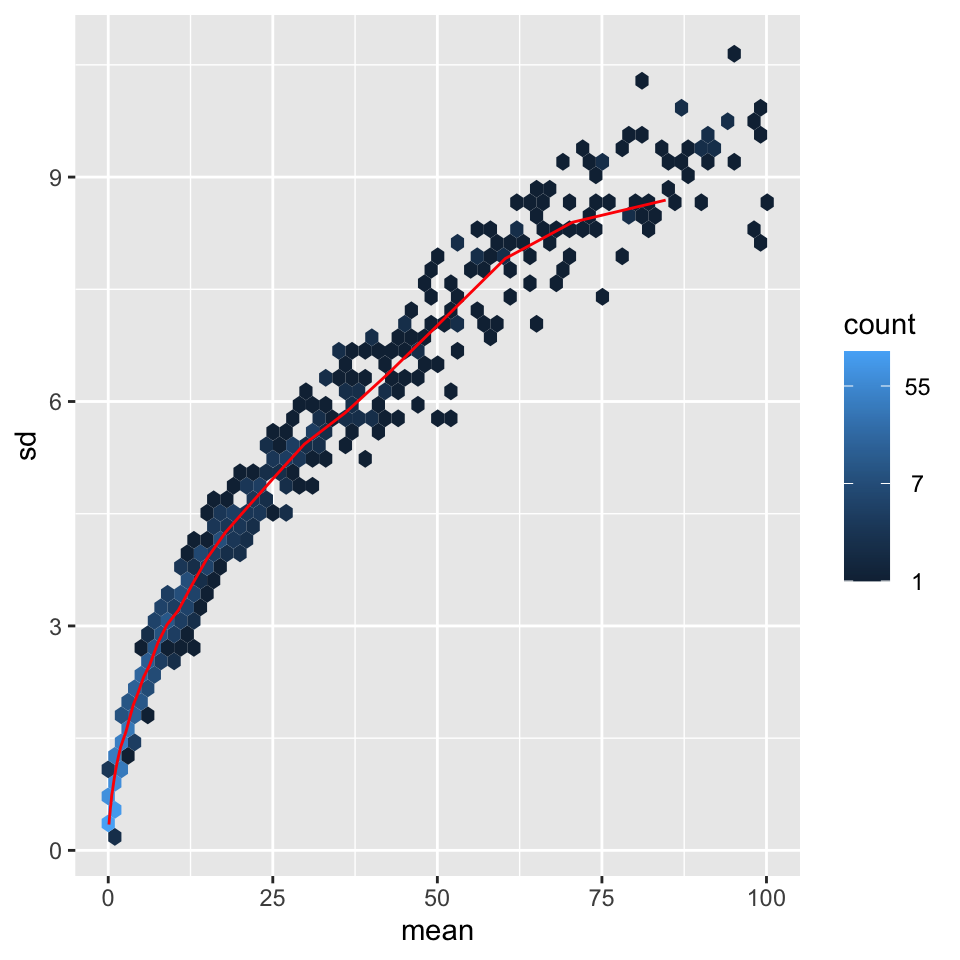

```r
lambda <- 10^seq(from = -1, to = 2, length = 1000)
cts <- matrix(rpois(1000*100, lambda), ncol = 100)
library("vsn")
meanSdPlot(cts, ranks = FALSE)
```

### Plot standard deviation of genes against the mean logarithm-transformed counts

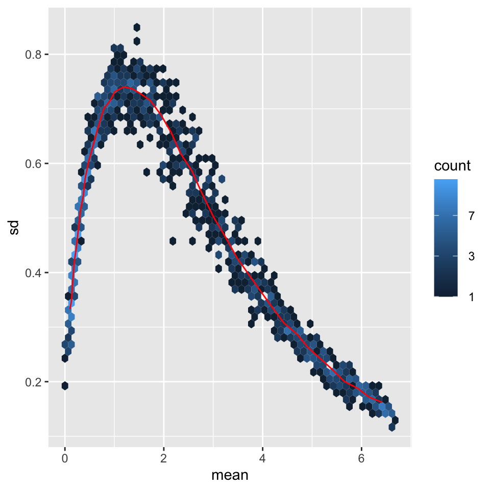

```r
log.cts.one <- log2(cts + 1)
meanSdPlot(log.cts.one, ranks = FALSE)
```

### Transform data with a *variance stabilizing transformation* using the function vst()

```r
vsd <- vst(dds, blind = FALSE)
head(assay(vsd), 3)
```

```
##                    SRR1039508 SRR1039509 SRR1039512 SRR1039513 SRR1039516
## ENSG00000000003.14  10.105781   9.852029  10.169726   9.991545  10.424865
## ENSG00000000419.12   9.692244   9.923647   9.801921   9.798653   9.763455
## ENSG00000000457.13   9.449592   9.312186   9.362754   9.459168   9.281415
##                    SRR1039517 SRR1039520 SRR1039521
## ENSG00000000003.14  10.194490  10.315814  10.002177
## ENSG00000000419.12   9.874703   9.683211   9.845507
## ENSG00000000457.13   9.395937   9.477971   9.477027
```

```r
colData(vsd)
```

```
## DataFrame with 8 rows and 5 columns
##                 names    donor     condition     cell      dex
##              <factor> <factor>      <factor> <factor> <factor>
## SRR1039508 SRR1039508   N61311     Untreated   N61311    untrt
## SRR1039509 SRR1039509   N61311 Dexamethasone   N61311      trt
## SRR1039512 SRR1039512  N052611     Untreated  N052611    untrt
## SRR1039513 SRR1039513  N052611 Dexamethasone  N052611      trt
## SRR1039516 SRR1039516  N080611     Untreated  N080611    untrt
## SRR1039517 SRR1039517  N080611 Dexamethasone  N080611      trt
## SRR1039520 SRR1039520  N061011     Untreated  N061011    untrt
## SRR1039521 SRR1039521  N061011 Dexamethasone  N061011      trt
```

### Transform data with a *regularized-logarithm transformation* using the function rlog()

```r
rld <- rlog(dds, blind = FALSE)
head(assay(rld), 3)
```

```
##                    SRR1039508 SRR1039509 SRR1039512 SRR1039513 SRR1039516
## ENSG00000000003.14   9.482613   9.172197   9.558383   9.346001   9.851349
## ENSG00000000419.12   8.860186   9.150196   9.000042   8.995902   8.951327
## ENSG00000000457.13   8.354790   8.166700   8.236582   8.366693   8.121781
##                    SRR1039517 SRR1039520 SRR1039521
## ENSG00000000003.14   9.587602   9.727248   9.357876
## ENSG00000000419.12   9.091075   8.848782   9.054384
## ENSG00000000457.13   8.282307   8.392384   8.391023
```

### Visualize the effects of the transformation

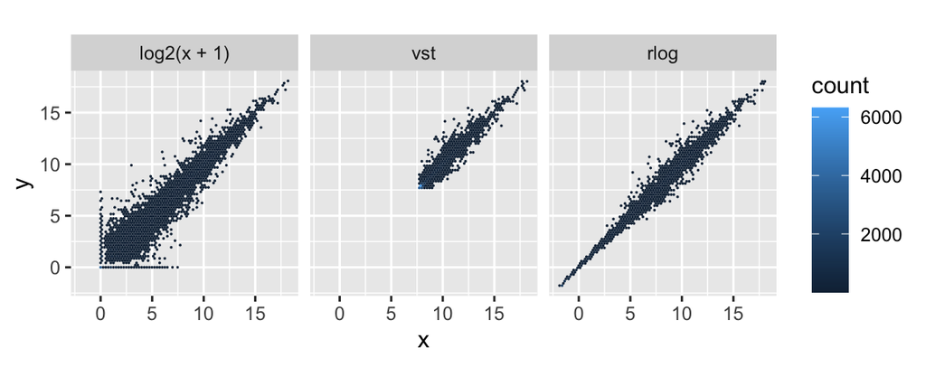

```r
library("dplyr")
library("ggplot2")

dds <- estimateSizeFactors(dds)

df <- bind_rows(
  as_data_frame(log2(counts(dds, normalized=TRUE)[, 1:2]+1)) %>%
         mutate(transformation = "log2(x + 1)"),
  as_data_frame(assay(vsd)[, 1:2]) %>% mutate(transformation = "vst"),
  as_data_frame(assay(rld)[, 1:2]) %>% mutate(transformation = "rlog"))

colnames(df)[1:2] <- c("x", "y")

lvls <- c("log2(x + 1)", "vst", "rlog")
df$transformation <- factor(df$transformation, levels=lvls)

ggplot(df, aes(x = x, y = y)) + geom_hex(bins = 80) +
  coord_fixed() + facet_grid( . ~ transformation)
```

## Sample distances

### Calculate the Euclidean distance between samples using the function dist()

```r
sampleDists <- dist(t(assay(vsd)))
sampleDists
```

```
##            SRR1039508 SRR1039509 SRR1039512 SRR1039513 SRR1039516 SRR1039517
## SRR1039509   39.42362
## SRR1039512   32.37620   44.93748
## SRR1039513   51.09677   37.18799   41.79886
## SRR1039516   35.59642   47.54671   34.83458   52.05265
## SRR1039517   51.26314   41.58572   46.89609   40.67315   39.74268
## SRR1039520   32.38578   46.96000   30.35980   48.08669   37.07106   50.38349
## SRR1039521   51.49108   37.57383   47.17283   31.45899   52.62276   41.35941
##            SRR1039520
## SRR1039509
## SRR1039512
## SRR1039513
## SRR1039516
## SRR1039517
## SRR1039520
## SRR1039521   43.01502
```

### Upload the packages pheatmap and RColorBrewer

```r
library("pheatmap")
library("RColorBrewer")
```

### Plot the Euclidean distances on a heatmap using the function pheatmap()

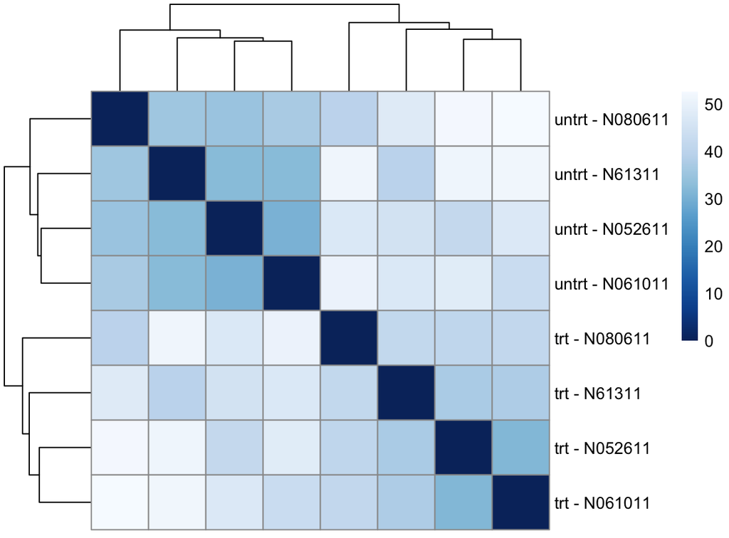

```r
sampleDistMatrix <- as.matrix( sampleDists )
rownames(sampleDistMatrix) <- paste( vsd$dex, vsd$cell, sep = " - " )
colnames(sampleDistMatrix) <- NULL
colors <- colorRampPalette( rev(brewer.pal(9, "Blues")) )(255)
pheatmap(sampleDistMatrix,
         clustering_distance_rows = sampleDists,
         clustering_distance_cols = sampleDists,
         col = colors)
```

### Calculate sample distances with Poisson distance using function PoissonDistance() in the PoiClaClu package

```r
library("PoiClaClu")
poisd <- PoissonDistance(t(counts(dds)))
```

### Plot Poisson sample distances on a heatmap using the function pheatmap()

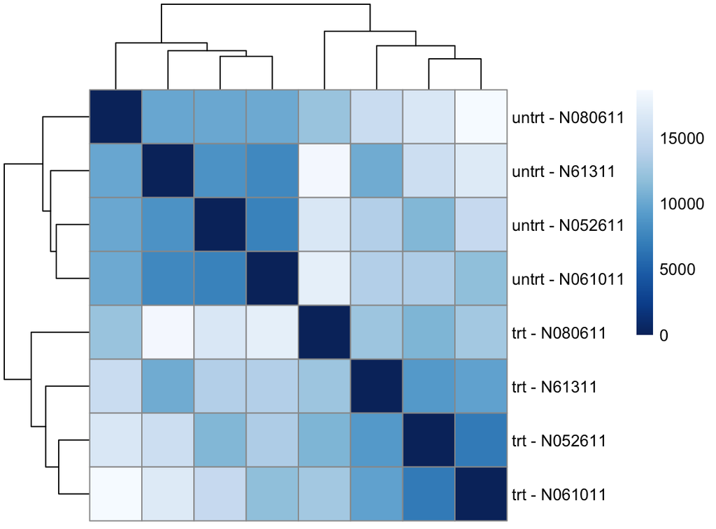

```r
samplePoisDistMatrix <- as.matrix( poisd$dd )
rownames(samplePoisDistMatrix) <- paste( dds$dex, dds$cell, sep=" - " )
colnames(samplePoisDistMatrix) <- NULL
pheatmap(samplePoisDistMatrix,
         clustering_distance_rows = poisd$dd,
         clustering_distance_cols = poisd$dd,
         col = colors)
```

## PCA plot

### Visualize sample-to-sample distances using principal component analysis via the function plotPCA()

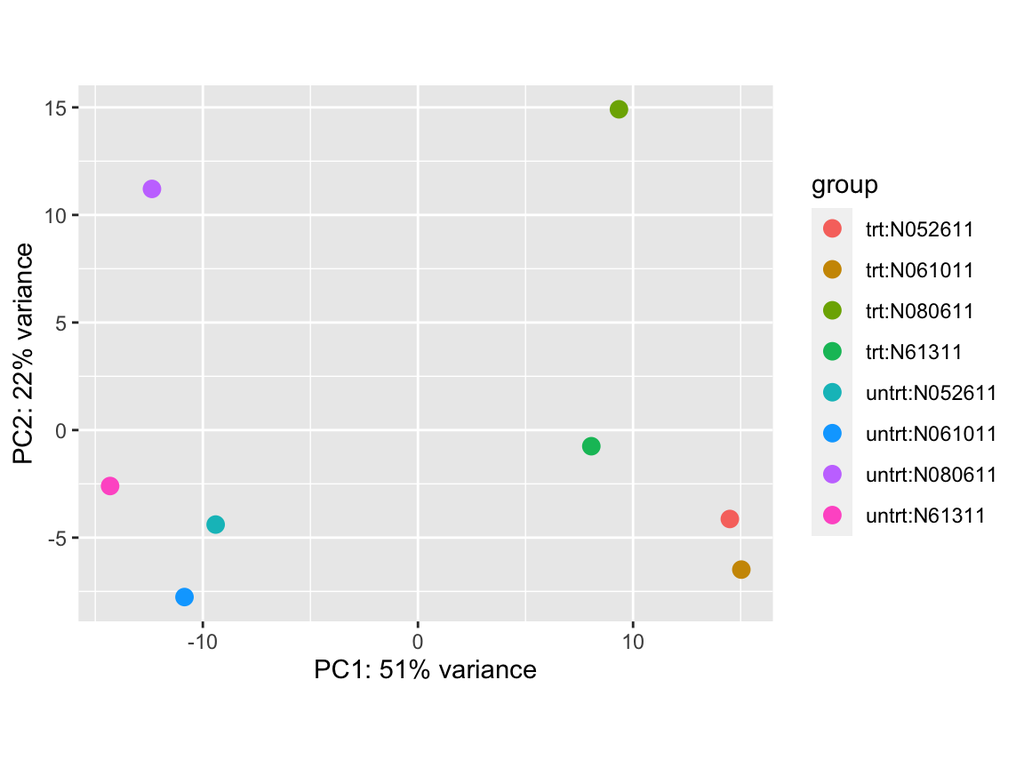

```r
plotPCA(vsd, intgroup = c("dex", "cell"))
```

### Build PCA plot using the ggplot2 package

```r
pcaData <- plotPCA(vsd, intgroup = c( "dex", "cell"), returnData = TRUE)
pcaData
```

```
##                   PC1        PC2         group   dex    cell       name
## SRR1039508 -14.311369 -2.6000421  untrt:N61311 untrt  N61311 SRR1039508
## SRR1039509   8.058574 -0.7500532    trt:N61311   trt  N61311 SRR1039509
## SRR1039512  -9.404122 -4.3920761 untrt:N052611 untrt N052611 SRR1039512
## SRR1039513  14.497842 -4.1323833   trt:N052611   trt N052611 SRR1039513
## SRR1039516 -12.365055 11.2109581 untrt:N080611 untrt N080611 SRR1039516
## SRR1039517   9.343946 14.9115160   trt:N080611   trt N080611 SRR1039517
## SRR1039520 -10.852633 -7.7618618 untrt:N061011 untrt N061011 SRR1039520
## SRR1039521  15.032816 -6.4860576   trt:N061011   trt N061011 SRR1039521
```

```r
percentVar <- round(100 * attr(pcaData, "percentVar"))
```

### Visualize sample-to-sample distances with color representing treatment and shape representign the cell line

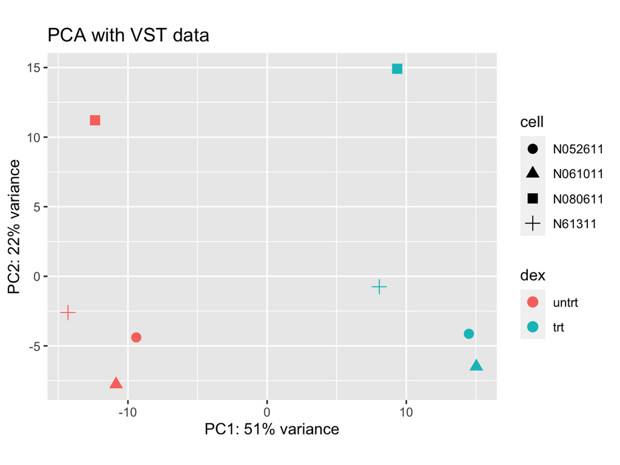

```r
ggplot(pcaData, aes(x = PC1, y = PC2, color = dex, shape = cell)) +
  geom_point(size =3) +
  xlab(paste0("PC1: ", percentVar[1], "% variance")) +
  ylab(paste0("PC2: ", percentVar[2], "% variance")) +
  coord_fixed() +
  ggtitle("PCA with VST data")
```

## PCA plot using Generalized PCA

### Perform dimension reduction on data using generalized PCA using the function glmpca() from the package glmpca

```r
library("glmpca")
gpca <- glmpca(counts(dds), L=2)
gpca.dat <- gpca$factors
gpca.dat$dex <- dds$dex
gpca.dat$cell <- dds$cell
```

### Visualize generalized PCA plot

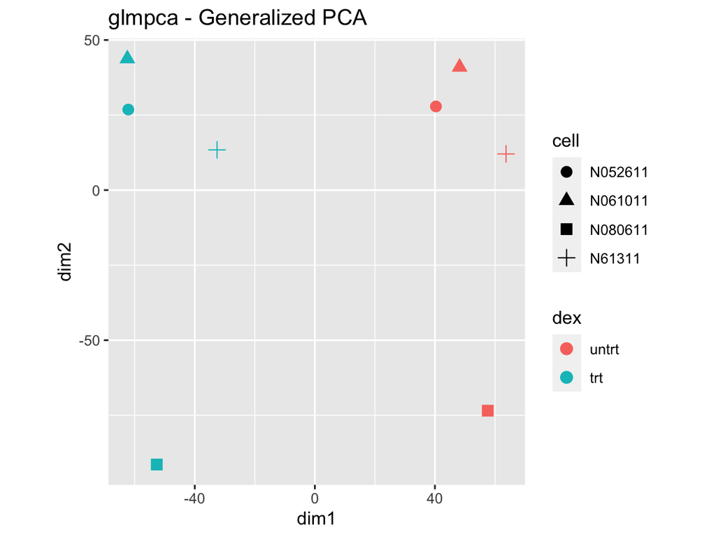

```r
ggplot(gpca.dat, aes(x = dim1, y = dim2, color = dex, shape = cell)) +
  geom_point(size =3) + coord_fixed() + ggtitle("glmpca - Generalized PCA")
```

## MDS plot

### Use multidimensional scaling (MDS) for the VST distances and then visualize them in a plot

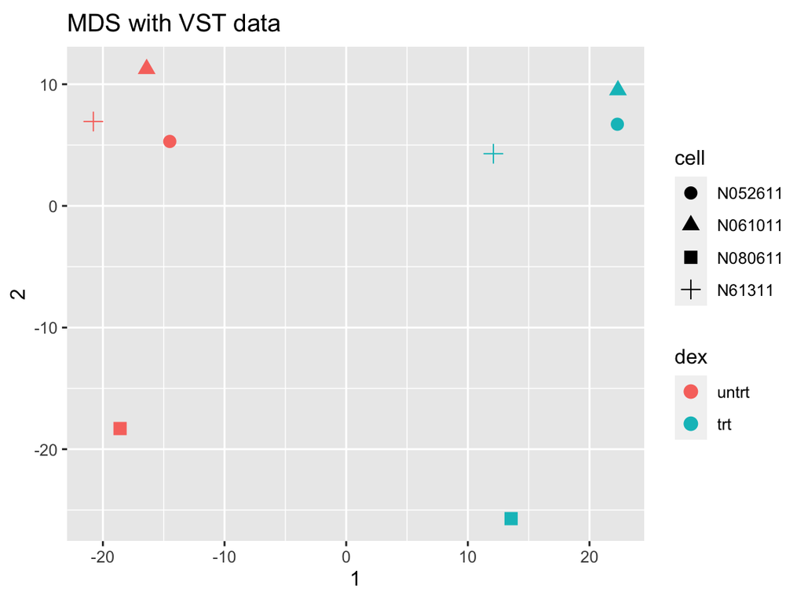

```r
mds <- as.data.frame(colData(vsd))  %>%
         cbind(cmdscale(sampleDistMatrix))
ggplot(mds, aes(x = `1`, y = `2`, color = dex, shape = cell)) +
  geom_point(size = 3) + coord_fixed() + ggtitle("MDS with VST data")
```

### Use multidimensional scaling (MDS) for the PoissonDistance distances and then visualize them in a plot

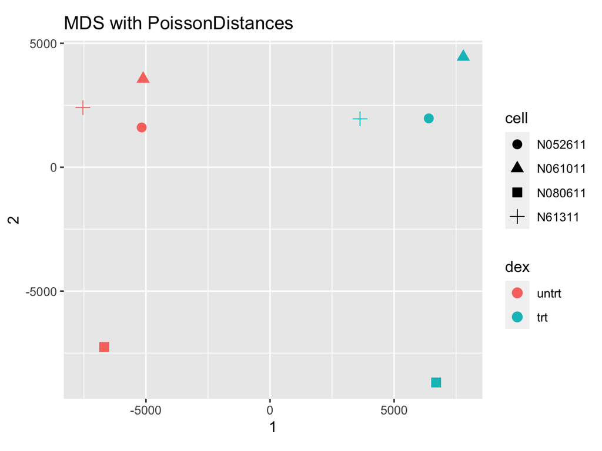

```r
mdsPois <- as.data.frame(colData(dds)) %>%
   cbind(cmdscale(samplePoisDistMatrix))
ggplot(mdsPois, aes(x = `1`, y = `2`, color = dex, shape = cell)) +
  geom_point(size = 3) + coord_fixed() + ggtitle("MDS with PoissonDistances")
```

## Differential expression analysis

## Running the differential expression pipeline

### Run the differential expression pipeline on raw counts using the function DESeq()

```r
dds <- DESeq(dds)
```

## Building the results table

### Extract the estimated log2 fold changes and p values for the last variable in the design formula using the function results()

```r
res <- results(dds)
res
```

```
## log2 fold change (MLE): dex trt vs untrt
## Wald test p-value: dex trt vs untrt
## DataFrame with 31604 rows and 6 columns
##                             baseMean      log2FoldChange             lfcSE
##                            <numeric>           <numeric>         <numeric>
## ENSG00000000003.14  739.940717372053  -0.361153676816704 0.106868570706213
## ENSG00000000419.12   511.73572199559   0.206314742225697 0.128664534265382
## ENSG00000000457.13  314.194855097564   0.037830765702789 0.158633410116225
## ENSG00000000460.16  79.7936215457165  -0.115258993162199 0.314990674190846
## ENSG00000000938.12 0.307266835513683   -1.36911852155525  3.50376358863452
## ...                              ...                 ...               ...
## ENSG00000285979.1   38.3538864147071   0.342365713888024 0.359510635836304
## ENSG00000285987.1   1.56250793343253   0.706414476454889   1.5472945399791
## ENSG00000285990.1  0.642314540619725   0.364733264633251  3.43327565299413
## ENSG00000285991.1   11.2762841129775  -0.116551517129412 0.748601160880117
## ENSG00000285994.1   3.65104108073599 -0.0960094332693204   1.0686598396981
##                                  stat               pvalue                padj
##                             <numeric>            <numeric>           <numeric>
## ENSG00000000003.14  -3.37941898567666 0.000726392125305196 0.00531136916201091
## ENSG00000000419.12   1.60350902759384    0.108822317644649   0.293188699547079
## ENSG00000000457.13  0.238479180867837    0.811509460868018    0.92255697455246
## ENSG00000000460.16 -0.365912398702847    0.714430444201867   0.872980377910416
## ENSG00000000938.12 -0.390756535628255    0.695977205170472                  NA
## ...                               ...                  ...                 ...
## ENSG00000285979.1   0.952310390182487    0.340939589953335   0.600750489158651
## ENSG00000285987.1   0.456548160807465    0.647995846834697                  NA
## ENSG00000285990.1   0.106234774453712    0.915396081024322                  NA
## ENSG00000285991.1  -0.155692407679924    0.876275481983982   0.952921308734717
## ENSG00000285994.1  -0.089840966884695    0.928413592935384                  NA
```

### Extract the estimated log2 fold changes and p values for only the two levels of dex treatment using contrast argument

```r
res <- results(dds, contrast=c("dex","trt","untrt"))
```

### Show metadata of the previous created DataFrame object using the function mcols()

```r
mcols(res, use.names = TRUE)
```

```
## DataFrame with 6 rows and 2 columns
##                        type                               description
##                 <character>                               <character>
## baseMean       intermediate mean of normalized counts for all samples
## log2FoldChange      results  log2 fold change (MLE): dex trt vs untrt
## lfcSE               results          standard error: dex trt vs untrt
## stat                results          Wald statistic: dex trt vs untrt
## pvalue              results       Wald test p-value: dex trt vs untrt
## padj                results                      BH adjusted p-values
```

### Summarize the results using the function summary()

```r
summary(res)
```

```
##
## out of 31604 with nonzero total read count
## adjusted p-value < 0.1
## LFC > 0 (up)       : 2373, 7.5%
## LFC < 0 (down)     : 1949, 6.2%
## outliers [1]       : 0, 0%
## low counts [2]     : 14706, 47%
## (mean count < 9)
## [1] see 'cooksCutoff' argument of ?results
## [2] see 'independentFiltering' argument of ?results
```

### Lower the false discovery rate (FDR) to 0.05

```r
res.05 <- results(dds, alpha = 0.05)
table(res.05$padj < 0.05)
```

```
##
## FALSE  TRUE
## 13357  3541
```

### Raise the log2 fold change threshold to show effects of treatment on gene counts more than doubling by specifying lfcThreshold = 1

```r
resLFC1 <- results(dds, lfcThreshold=1)
table(resLFC1$padj < 0.1)
```

```
##
## FALSE  TRUE
## 16687   211
```

**Note: you can find the citations of packages by typing citation(“pkgName”) in R. You should cite packages if, in a publication, you use results derived from them.**

## Other comparisons

### Extract results for the log2 of the fold change of one cell line over another

```r
results(dds, contrast = c("cell", "N061011", "N61311"))
```

```
## log2 fold change (MLE): cell N061011 vs N61311
## Wald test p-value: cell N061011 vs N61311
## DataFrame with 31604 rows and 6 columns
##                             baseMean      log2FoldChange             lfcSE
##                            <numeric>           <numeric>         <numeric>
## ENSG00000000003.14  739.940717372053   0.270945073288714 0.152170652747696
## ENSG00000000419.12   511.73572199559 -0.0718309515716049 0.182816709211393
## ENSG00000000457.13  314.194855097564    0.17988057135378 0.225122028264875
## ENSG00000000460.16  79.7936215457165  -0.119482058987533 0.441593831219506
## ENSG00000000938.12 0.307266835513683                   0   4.9975798104491
## ...                              ...                 ...               ...
## ENSG00000285979.1   38.3538864147071  0.0589757126275811 0.512391427449622
## ENSG00000285987.1   1.56250793343253    1.02168042060967  2.20186060481305
## ENSG00000285990.1  0.642314540619725   -3.09564035666317  4.85271500898552
## ENSG00000285991.1   11.2762841129775  -0.877962796217153  1.04696318967239
## ENSG00000285994.1   3.65104108073599 -0.0192350857348909   1.5132364065081
##                                   stat             pvalue              padj
##                              <numeric>          <numeric>         <numeric>
## ENSG00000000003.14    1.78053434349099 0.0749885539964457  0.37882768043907
## ENSG00000000419.12  -0.392912397786058  0.694384184390243  0.93670340928549
## ENSG00000000457.13   0.799035850646014  0.424269624416598 0.820732883668396
## ENSG00000000460.16  -0.270570036401033  0.786721743935893 0.960661528779669
## ENSG00000000938.12                   0                  1                NA
## ...                                ...                ...               ...
## ENSG00000285979.1    0.115098944806955  0.908366696268635 0.983709901493367
## ENSG00000285987.1     0.46400776614849  0.642642181542788                NA
## ENSG00000285990.1   -0.637919257762125  0.523526241080306                NA
## ENSG00000285991.1   -0.838580386471737   0.40170482075606                NA
## ENSG00000285994.1  -0.0127112232114989  0.989858184362336                NA
```

## Multiple testing

### Determine the number of genes with p value < 0.05 and total number of genes tested

```r
sum(res$pvalue < 0.05, na.rm=TRUE)
```

```
## [1] 5170
```

```r
sum(!is.na(res$pvalue))
```

```
## [1] 31604
```

### Determine number of genes with adjust p value < 0.1 as determined using the Benjamini-Hochberg adjustment for multiple testing

```r
sum(res$padj < 0.1, na.rm=TRUE)
```

```
## [1] 4322
```

### Subset the results table to the above genes and sort by log2 fold change estimate to rank significant genes starting with those most down-regulated

```r
resSig <- subset(res, padj < 0.1)
head(resSig[ order(resSig$log2FoldChange), ])
```

```
## log2 fold change (MLE): dex trt vs untrt
## Wald test p-value: dex trt vs untrt
## DataFrame with 6 rows and 6 columns
##                           baseMean    log2FoldChange             lfcSE
##                          <numeric>         <numeric>         <numeric>
## ENSG00000216490.3 42.3007106248874 -5.72482604043858  1.47565155349927
## ENSG00000267339.5 30.5206063861615 -5.39781111590036 0.773017198758288
## ENSG00000257542.5 10.0398869404764 -5.25991351125893  1.28200100388257
## ENSG00000146006.7 61.6448430808005 -4.49504194549369 0.663821044679586
## ENSG00000108700.4 14.6323552674909 -4.09068745839218 0.941842256424086
## ENSG00000213240.8  12.096158074824 -3.87312575409988  1.27413298748988
##                                stat               pvalue                 padj
##                           <numeric>            <numeric>            <numeric>
## ENSG00000216490.3 -3.87952428665362 0.000104660951388532 0.000987852735620848
## ENSG00000267339.5 -6.98278269173179 2.89389866967638e-12  9.4586266383349e-11
## ENSG00000257542.5 -4.10289344183752 4.08015195589968e-05 0.000430645894758231
## ENSG00000146006.7 -6.77146646904417 1.27483509915645e-11 3.82631678606496e-10
## ENSG00000108700.4 -4.34328299722226 1.40369125072207e-05  0.00016668710298455
## ENSG00000213240.8 -3.03981279201488  0.00236725244353312   0.0144986704569854
```

### Same thing as above EXCEPT ranking genes starting with those that are most upregulated

```r
head(resSig[ order(resSig$log2FoldChange, decreasing = TRUE), ])
```

```
## log2 fold change (MLE): dex trt vs untrt
## Wald test p-value: dex trt vs untrt
## DataFrame with 6 rows and 6 columns
##                            baseMean   log2FoldChange             lfcSE
##                           <numeric>        <numeric>         <numeric>
## ENSG00000254692.1  62.2302142486739 10.2071429096331  3.37705826771585
## ENSG00000179593.15 67.0895286534166 9.50514812098004  1.07705493413338
## ENSG00000268173.3  46.4370434386407 8.40438119076897  3.38505617991746
## ENSG00000224712.12 35.5607475035812 7.16685536619654  2.16475512121352
## ENSG00000109906.13 438.193981971508 6.37749569519001 0.313810468763182
## ENSG00000257663.1  24.3946124843467 6.34758399422488  2.09531382411201
##                                stat               pvalue                 padj
##                           <numeric>            <numeric>            <numeric>
## ENSG00000254692.1   3.0224953496396  0.00250699934752643   0.0152166935971629
## ENSG00000179593.15 8.82512843100996 1.09334265101889e-18 6.81745539369636e-17
## ENSG00000268173.3  2.48278927854424   0.0130358175653821   0.0594385443118797
## ENSG00000224712.12  3.3107002708828 0.000930628316571692  0.00655239887226186
## ENSG00000109906.13 20.3227627182916 8.08933590301556e-92 1.24266907353779e-88
## ENSG00000257663.1  3.02941923122899  0.00245024410719956   0.0149150666150786
```

## Counts plot

### Visualize the counts for a particular gene using the function plotCounts()

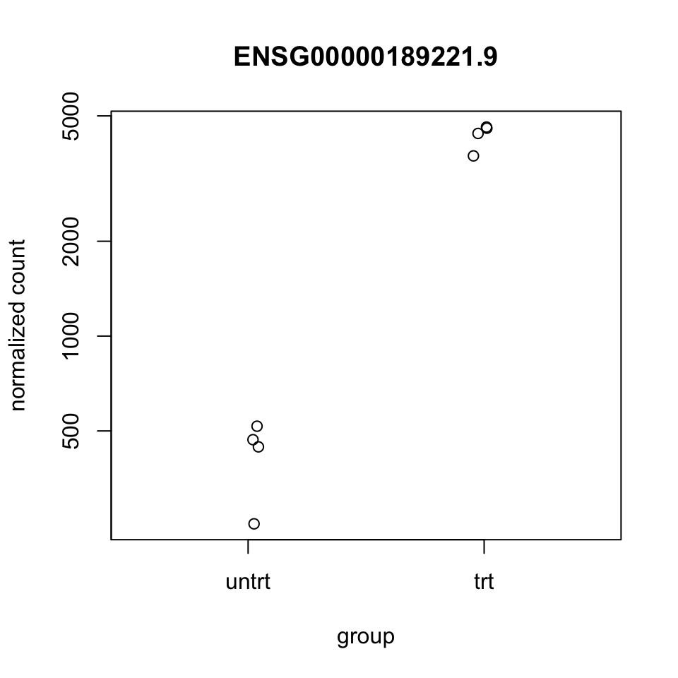

```r
topGene <- rownames(res)[which.min(res$padj)]
plotCounts(dds, gene = topGene, intgroup=c("dex"))
```

### Visualize counts with a customized plot using ggplot()

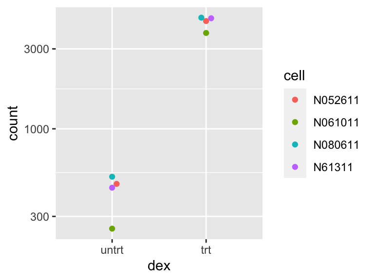

```r
library("ggbeeswarm")
geneCounts <- plotCounts(dds, gene = topGene, intgroup = c("dex","cell"),
                         returnData = TRUE)
ggplot(geneCounts, aes(x = dex, y = count, color = cell)) +
  scale_y_log10() +  geom_beeswarm(cex = 3)
```

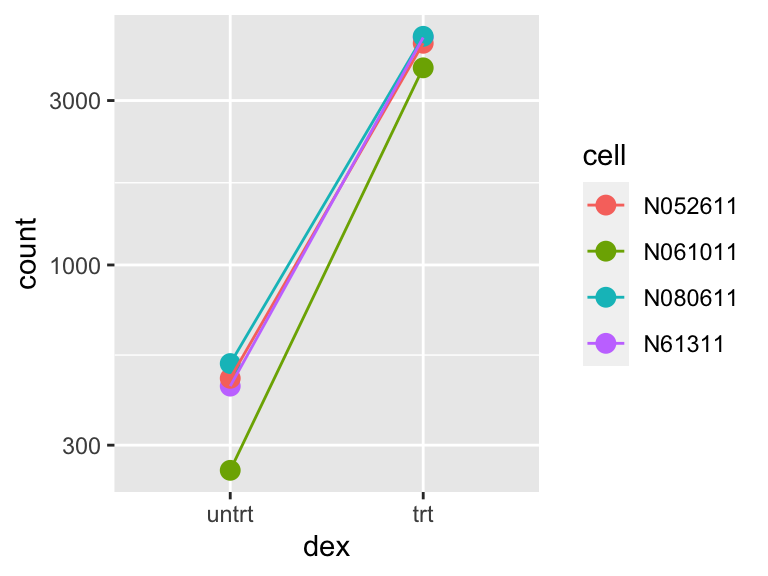

```r
ggplot(geneCounts, aes(x = dex, y = count, color = cell, group = cell)) +
  scale_y_log10() + geom_point(size = 3) + geom_line()
```

## MA-plot

### Determine the coefficients of the model using the function resultsNames(), shrink the dex_trt_vs_untrt coefficient using the apeglm method, and visualize the distribution of the estimated coefficient using a MA-plot/mean-difference plot/Bland-Altman plot.

```r
library("apeglm")
resultsNames(dds)
```

```
## [1] "Intercept"               "cell_N061011_vs_N052611"
## [3] "cell_N080611_vs_N052611" "cell_N61311_vs_N052611"
## [5] "dex_trt_vs_untrt"
```

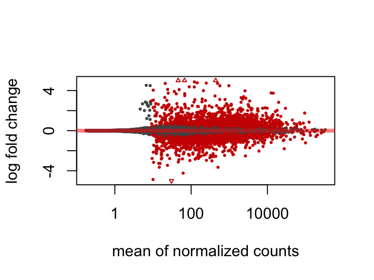

```r
res <- lfcShrink(dds, coef="dex_trt_vs_untrt", type="apeglm")
plotMA(res, ylim = c(-5, 5))
```

### Plot estimated coefficient without shrinking using a MA-plot

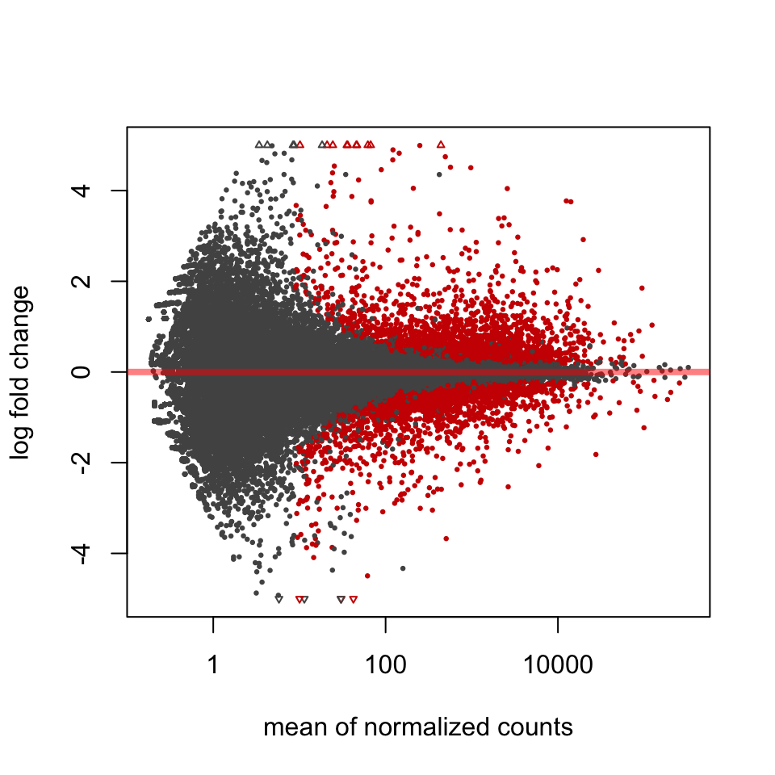

```r
res.noshr <- results(dds, name="dex_trt_vs_untrt")
plotMA(res.noshr, ylim = c(-5, 5))
```

### Label an individual point on the MA-plot

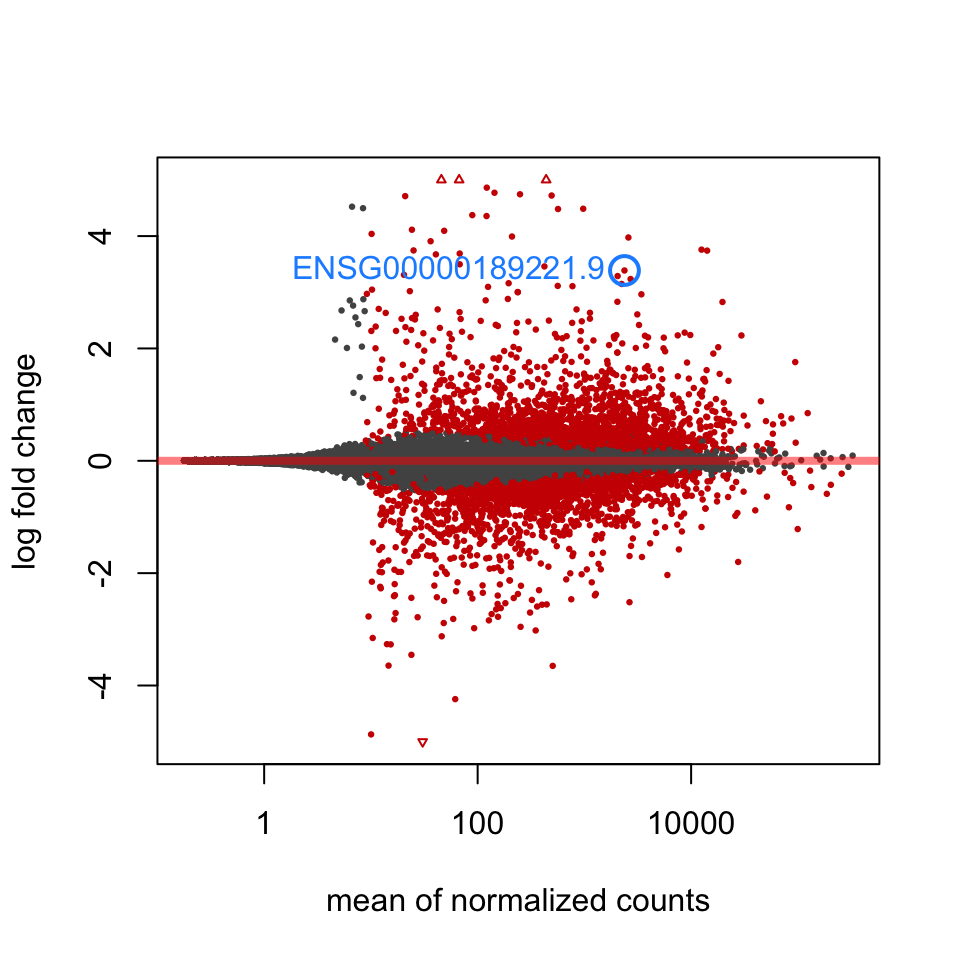

```r
plotMA(res, ylim = c(-5,5))
topGene <- rownames(res)[which.min(res$padj)]
with(res[topGene, ], {
  points(baseMean, log2FoldChange, col="dodgerblue", cex=2, lwd=2)
  text(baseMean, log2FoldChange, topGene, pos=2, col="dodgerblue")
})
```

### Plot a histogram of the p-values while including only those genes with mean normalized count larger than 1

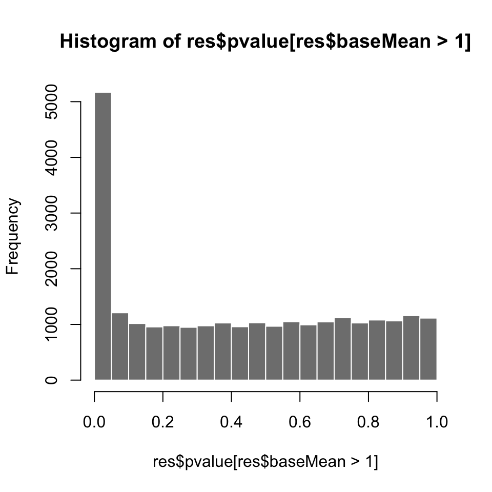

```r
hist(res$pvalue[res$baseMean > 1], breaks = 0:20/20,
     col = "grey50", border = "white")
```

## Gene clustering

### Select the 20 genes with the highest variance across samples from the VST data

```r
library("genefilter")
topVarGenes <- head(order(rowVars(assay(vsd)), decreasing = TRUE), 20)
```

### Center each genes’ values across samples and plot a heatmap

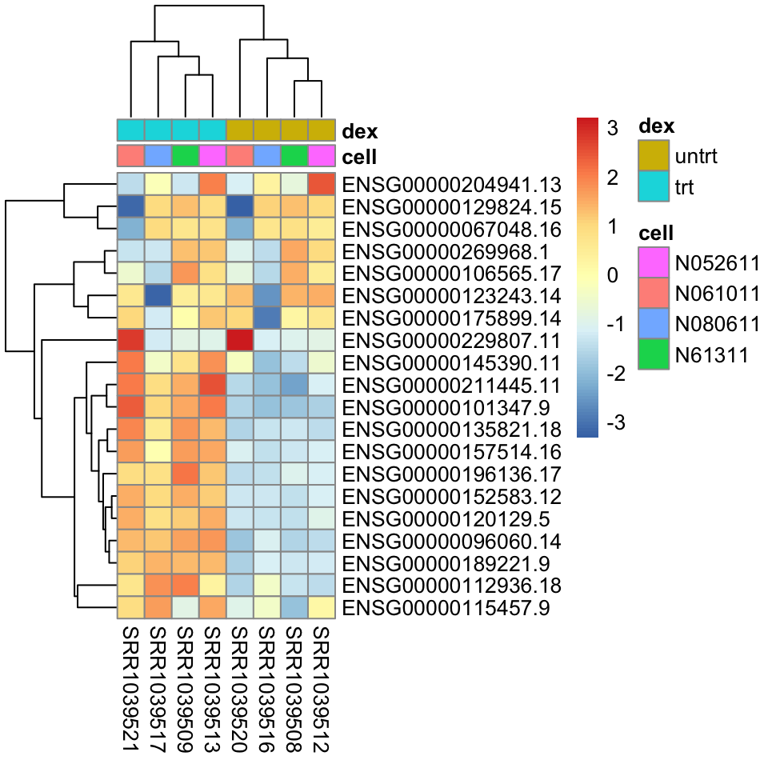

```r
mat  <- assay(vsd)[ topVarGenes, ]
mat  <- mat - rowMeans(mat)
anno <- as.data.frame(colData(vsd)[, c("cell","dex")])
pheatmap(mat, annotation_col = anno)
```

## Independent filtering

### Create bins using the function quantile(), bin the genes by base mean using the function cut(), rename the levels of the bins using the middle point, calculate the ratio of p values less 0.05 for each bin, and plot the ratios

**[Note: this process is known as independent filtering, which improves power with multiple testing]**

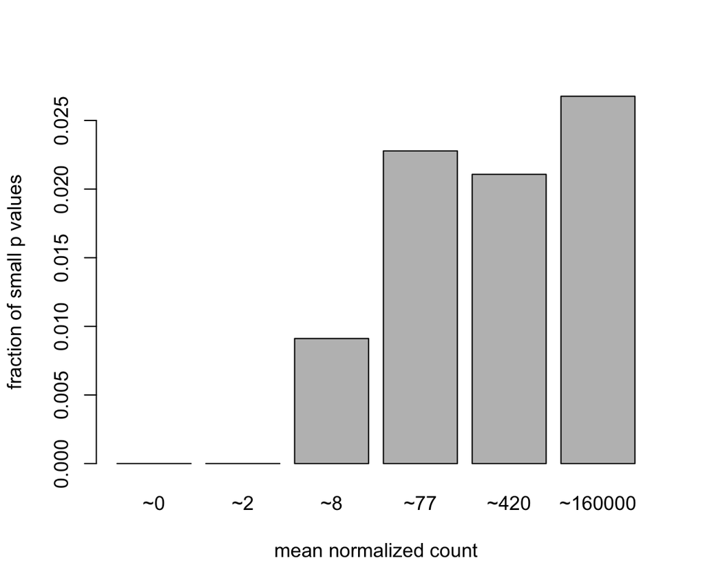

```r
qs <- c(0, quantile(resLFC1$baseMean[resLFC1$baseMean > 0], 0:6/6))
bins <- cut(resLFC1$baseMean, qs)
levels(bins) <- paste0("~", round(signif((qs[-1] + qs[-length(qs)])/2, 2)))
fractionSig <- tapply(resLFC1$pvalue, bins, function(p)
                          mean(p < .05, na.rm = TRUE))
barplot(fractionSig, xlab = "mean normalized count",
                     ylab = "fraction of small p values")
```

## Independent hypothesis weighting

### Instead of independent filtering, weight hypotheses to optimize power using the ihw function in the IHW package

```r
#  library("IHW")
#  res.ihw <- results(dds, filterFun=ihw)
```

## Annotating and exporting results

### Load the packages AnnotationDbi and org.Hs.eg.db

```r
library("AnnotationDbi")
library("org.Hs.eg.db")
```

### Get a list of all available key types using the function columns()

```r
columns(org.Hs.eg.db)
```

```
##  [1] "ACCNUM"       "ALIAS"        "ENSEMBL"      "ENSEMBLPROT"  "ENSEMBLTRANS"
##  [6] "ENTREZID"     "ENZYME"       "EVIDENCE"     "EVIDENCEALL"  "GENENAME"
## [11] "GO"           "GOALL"        "IPI"          "MAP"          "OMIM"
## [16] "ONTOLOGY"     "ONTOLOGYALL"  "PATH"         "PFAM"         "PMID"
## [21] "PROSITE"      "REFSEQ"       "SYMBOL"       "UCSCKG"       "UNIGENE"
## [26] "UNIPROT"
```

### Use the function mapIds() to add individual columns to the results table

```r
ens.str <- substr(rownames(res), 1, 15)
res$symbol <- mapIds(org.Hs.eg.db,
                     keys=ens.str,
                     column="SYMBOL",
                     keytype="ENSEMBL",
                     multiVals="first")
res$entrez <- mapIds(org.Hs.eg.db,
                     keys=ens.str,
                     column="ENTREZID",
                     keytype="ENSEMBL",
                     multiVals="first")
```

### Arrange the results by p value and view the head of the DataFrame

```r
resOrdered <- res[order(res$pvalue),]
head(resOrdered)
```

```
## log2 fold change (MAP): dex trt vs untrt
## Wald test p-value: dex trt vs untrt
## DataFrame with 6 rows and 7 columns
##                            baseMean   log2FoldChange             lfcSE
##                           <numeric>        <numeric>         <numeric>
## ENSG00000189221.9  2373.80530666857 3.38765439100121 0.136984725340872
## ENSG00000120129.5  3420.72722668767 2.96334836319586 0.120849818517125
## ENSG00000101347.9  14125.5841210142 3.74129175571393 0.157926779740445
## ENSG00000196136.17 2710.21742603852 3.23518345105418 0.143950996111791
## ENSG00000152583.12 974.737366684742 4.48640613542985 0.201275651989011
## ENSG00000211445.11 12512.7915263227 3.75874563219025 0.169535830279915
##                                   pvalue                  padj      symbol
##                                <numeric>             <numeric> <character>
## ENSG00000189221.9  1.84493931066867e-137 3.11757844716792e-133        MAOA
## ENSG00000120129.5   6.3504237592554e-135 5.36547303419488e-131       DUSP1
## ENSG00000101347.9  2.88983300388474e-127 1.62774660332148e-123      SAMHD1
## ENSG00000196136.17 3.68488166768093e-114 1.55667826051181e-110    SERPINA3
## ENSG00000152583.12 2.94551443785581e-113  9.9546605941775e-110     SPARCL1
## ENSG00000211445.11 2.36246306534271e-112 6.65348347969353e-109        GPX3
##                         entrez
##                    <character>
## ENSG00000189221.9         4128
## ENSG00000120129.5         1843
## ENSG00000101347.9        25939
## ENSG00000196136.17          12
## ENSG00000152583.12        8404
## ENSG00000211445.11        2878
```

## Exporting Results

### Save the results table as a CSV file using the function write.csv()

```r
#  resOrderedDF <- as.data.frame(resOrdered)[1:100, ]
#  write.csv(resOrderedDF, file = "results.csv")
```

### Create a dynamic ReportingTools report which includes links to external databases using gene identifiers and boxplots summarizing the normalized counts across groups

```r
#  library("ReportingTools")
#  htmlRep <- HTMLReport(shortName="report", title="My report",
#                        reportDirectory="./report")
#  publish(resOrderedDF, htmlRep)
#  url <- finish(htmlRep)
#  browseURL(url)
```

## Plotting fold changes in genomic space

### Instead of a DataFrame, return a GRanges object using the argument format and specifying GRanges

```r
resGR <- lfcShrink(dds, coef="dex_trt_vs_untrt", type="apeglm", format="GRanges")
resGR
```

```
## GRanges object with 31604 ranges and 5 metadata columns:
##                      seqnames              ranges strand |          baseMean
##                         <Rle>           <IRanges>  <Rle> |         <numeric>
##   ENSG00000000003.14     chrX 100627109-100639991      - |  739.940717372053
##   ENSG00000000419.12    chr20   50934867-50958555      - |   511.73572199559
##   ENSG00000000457.13     chr1 169849631-169894267      - |  314.194855097564
##   ENSG00000000460.16     chr1 169662007-169854080      + |  79.7936215457165
##   ENSG00000000938.12     chr1   27612064-27635277      - | 0.307266835513683
##                  ...      ...                 ...    ... .               ...
##    ENSG00000285979.1    chr16   57177349-57181390      + |  38.3538864147071
##    ENSG00000285987.1     chr9   84316514-84657077      + |  1.56250793343253
##    ENSG00000285990.1    chr14   19244904-19269380      - | 0.642314540619725
##    ENSG00000285991.1     chr6 149817937-149896011      - |  11.2762841129775
##    ENSG00000285994.1    chr10   12563151-12567351      + |  3.65104108073599
##                             log2FoldChange             lfcSE
##                                  <numeric>         <numeric>
##   ENSG00000000003.14    -0.336004620197314 0.105908878209215
##   ENSG00000000419.12     0.178378944093913 0.122440452558955
##   ENSG00000000457.13    0.0299360694683492 0.141095483475456
##   ENSG00000000460.16   -0.0555061349569227 0.222786670799123
##   ENSG00000000938.12   -0.0115799289067039  0.30473963728621
##                  ...                   ...               ...
##    ENSG00000285979.1      0.15284386124239 0.257069545767735
##    ENSG00000285987.1    0.0255152677225242 0.300687312203615
##    ENSG00000285990.1 -0.000185630381439551 0.304464769734699
##    ENSG00000285991.1   -0.0150788219861866 0.283931479729372
##    ENSG00000285994.1  -0.00684681225244801 0.293399449125489
##                                    pvalue                padj
##                                 <numeric>           <numeric>
##   ENSG00000000003.14 0.000726392125305196 0.00531136916201091
##   ENSG00000000419.12    0.108822317644649   0.293188699547079
##   ENSG00000000457.13    0.811509460868018    0.92255697455246
##   ENSG00000000460.16    0.714430444201867   0.872980377910416
##   ENSG00000000938.12    0.695977205170472                <NA>
##                  ...                  ...                 ...
##    ENSG00000285979.1    0.340939589953335   0.600750489158651
##    ENSG00000285987.1    0.647995846834697                <NA>
##    ENSG00000285990.1    0.915396081024322                <NA>
##    ENSG00000285991.1    0.876275481983982   0.952921308734717
##    ENSG00000285994.1    0.928413592935384                <NA>
##   -------
##   seqinfo: 25 sequences (1 circular) from hg38 genome
```

### Add symbol again for labeling the genes on the plot

```r
ens.str <- substr(names(resGR), 1, 15)
resGR$symbol <- mapIds(org.Hs.eg.db, ens.str, "SYMBOL", "ENSEMBL")
```

### Load the Gviz package

```r
library("Gviz")
```

### Specify a window of 1 million base pairs upstream and downstream from the gene with the smallest p value

```r
window <- resGR[topGene] + 1e6
strand(window) <- "*"
resGRsub <- resGR[resGR %over% window]
naOrDup <- is.na(resGRsub$symbol) | duplicated(resGRsub$symbol)
resGRsub$group <- ifelse(naOrDup, names(resGRsub), resGRsub$symbol)
```

### Create a vector specifying the genes in the subset having a low value of padj

```r
status <- factor(ifelse(resGRsub$padj < 0.05 & !is.na(resGRsub$padj),
                        "sig", "notsig"))
```

### Plot the results using the Gvis functions: GenomeAxisTrack(), AnnotationTrack(), DataTrack(), plotTracks()

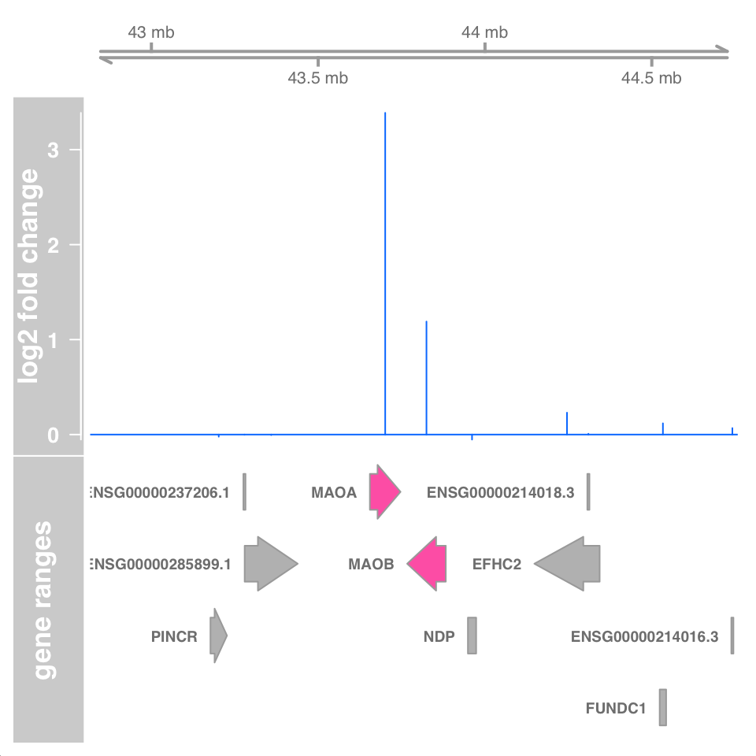

```r
options(ucscChromosomeNames = FALSE)
g <- GenomeAxisTrack()
a <- AnnotationTrack(resGRsub, name = "gene ranges", feature = status)
d <- DataTrack(resGRsub, data = "log2FoldChange", baseline = 0,
               type = "h", name = "log2 fold change", strand = "+")
plotTracks(list(g, d, a), groupAnnotation = "group",
           notsig = "grey", sig = "hotpink")
```

## Removing hidden batch effects

## Using SVA with DESeq2

### Load the sva package

```r
library("sva")
```

### Obtain a matrix of normalized counts for which the average count across samples is > 1, use a full model matrix with the dex variable and a reduced model matrix with only an intercept term, and specify that 2 surrogate variables are wanted

```r
dat  <- counts(dds, normalized = TRUE)
idx  <- rowMeans(dat) > 1
dat  <- dat[idx, ]
mod  <- model.matrix(~ dex, colData(dds))
mod0 <- model.matrix(~   1, colData(dds))
svseq <- svaseq(dat, mod, mod0, n.sv = 2)
```

```
## Number of significant surrogate variables is:  2
## Iteration (out of 5 ):1  2  3  4  5
```

```r
svseq$sv
```

```
##            [,1]        [,2]
## [1,]  0.2465669 -0.51599084
## [2,]  0.2588137 -0.59462876
## [3,]  0.1384516  0.24920662
## [4,]  0.2179075  0.37716083
## [5,] -0.6042910 -0.06305844
## [6,] -0.6138795 -0.03623320
## [7,]  0.1821306  0.30328185
## [8,]  0.1743002  0.28026195
```

### Determine how well the SVA method did at recovering the cell line variables

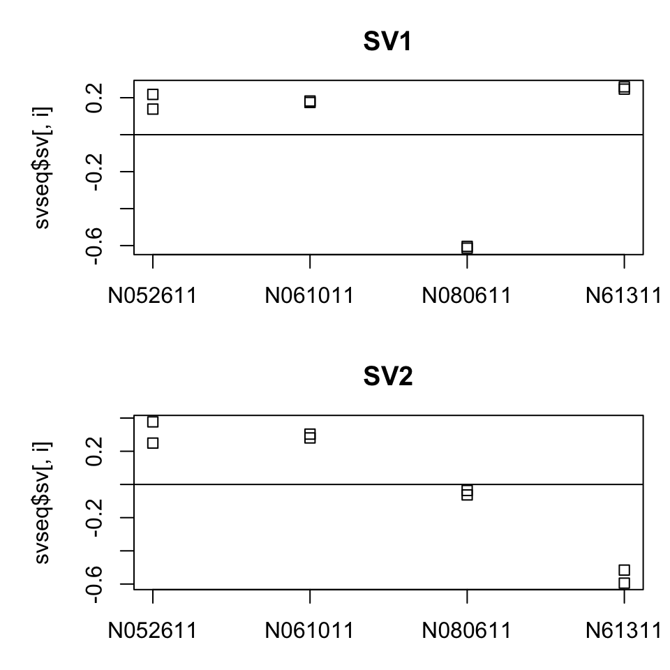

```r
par(mfrow = c(2, 1), mar = c(3,5,3,1))
for (i in 1:2) {
  stripchart(svseq$sv[, i] ~ dds$cell, vertical = TRUE, main = paste0("SV", i))
  abline(h = 0)
}
```

### Add the two surrogate variables as columns to the DESeqDataSet

```r
ddssva <- dds
ddssva$SV1 <- svseq$sv[,1]
ddssva$SV2 <- svseq$sv[,2]
design(ddssva) <- ~ SV1 + SV2 + dex
```

## Using RUV with DESeq2

### Load the RUVSeq package

```r
library("RUVSeq")
```

### Estimate factors of unwanted variation using the function RUVg()

```r
set <- newSeqExpressionSet(counts(dds))
idx  <- rowSums(counts(set) > 5) >= 2
set  <- set[idx, ]
set <- betweenLaneNormalization(set, which="upper")
not.sig <- rownames(res)[which(res$pvalue > .1)]
empirical <- rownames(set)[ rownames(set) %in% not.sig ]
set <- RUVg(set, empirical, k=2)
pData(set)
```

```
##                     W_1         W_2
## SRR1039508 -0.224881168  0.42992983
## SRR1039509 -0.249022928  0.53858506
## SRR1039512  0.001460949  0.01437385
## SRR1039513 -0.175547525  0.08408354
## SRR1039516  0.599387535 -0.02512358
## SRR1039517  0.590516825 -0.02549392
## SRR1039520 -0.241071948 -0.50369551
## SRR1039521 -0.300841739 -0.51265927
```

### Plot the factors estimated by RUV

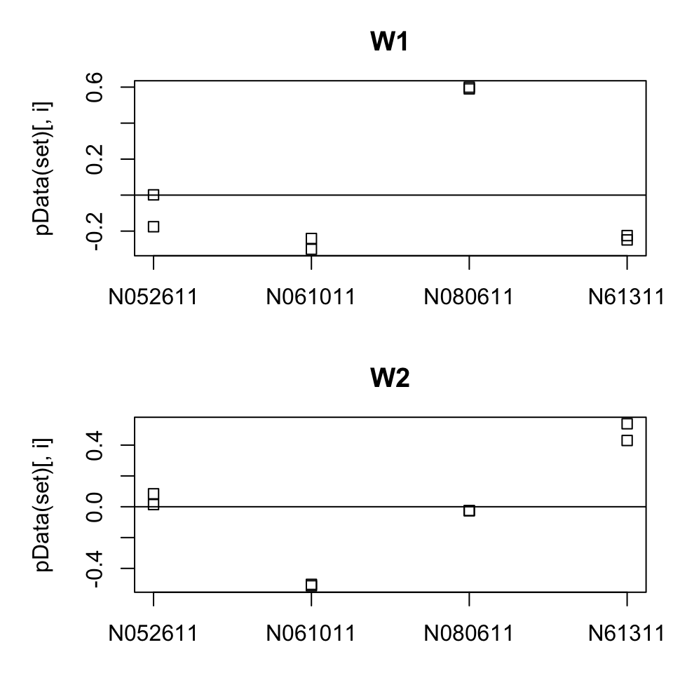

```r
par(mfrow = c(2, 1), mar = c(3,5,3,1))
for (i in 1:2) {
  stripchart(pData(set)[, i] ~ dds$cell, vertical = TRUE, main = paste0("W", i))
  abline(h = 0)
}
```

### Add factors to the DESeqDataSet as a means to control for them in future analysis

```r
ddsruv <- dds
ddsruv$W1 <- set$W_1
ddsruv$W2 <- set$W_2
design(ddsruv) <- ~ W1 + W2 + dex
```

## Time course experiments

### Upload the fission data and designate a design formula that models the strain difference at time 0, the difference over time, and any strain-specific differences over time

```r
library("fission")
data("fission")
ddsTC <- DESeqDataSet(fission, ~ strain + minute + strain:minute)
```

### Perform a likelihood ratio test using the function DESeq() indicating LRT for the test argument

```r
ddsTC <- DESeq(ddsTC, test="LRT", reduced = ~ strain + minute)
resTC <- results(ddsTC)
resTC$symbol <- mcols(ddsTC)$symbol
head(resTC[order(resTC$padj),], 4)
```

```
## log2 fold change (MLE): strainmut.minute180
## LRT p-value: '~ strain + minute + strain:minute' vs '~ strain + minute'
## DataFrame with 4 rows and 7 columns
##                      baseMean      log2FoldChange             lfcSE
##                     <numeric>           <numeric>         <numeric>
## SPBC2F12.09c 174.671161802578   -2.65671953167536 0.752261272510079
## SPAC1002.18  444.504950375698 -0.0509321395113243  0.20429948485572
## SPAC1002.19  336.373206596558  -0.392748982380861 0.573494009173123
## SPAC1002.17c 261.773132733438   -1.13876476912802  0.60612875682789
##                          stat               pvalue                 padj
##                     <numeric>            <numeric>            <numeric>
## SPBC2F12.09c  97.283386406583 1.97415107461335e-19 1.33452612643862e-15
## SPAC1002.18   56.953598622801 5.16955159226891e-11 1.74730843818689e-07
## SPAC1002.19  43.5339085770392 2.87980357353034e-08 6.48915738568838e-05
## SPAC1002.17c 39.3158355351511 2.05137078380187e-07 0.000346681662462517
##                   symbol
##              <character>
## SPBC2F12.09c       atf21
## SPAC1002.18         urg3
## SPAC1002.19         urg1
## SPAC1002.17c        urg2
```

### For the gene with the smallest adjusted p value, plot the counts for the groups over time using ggplot

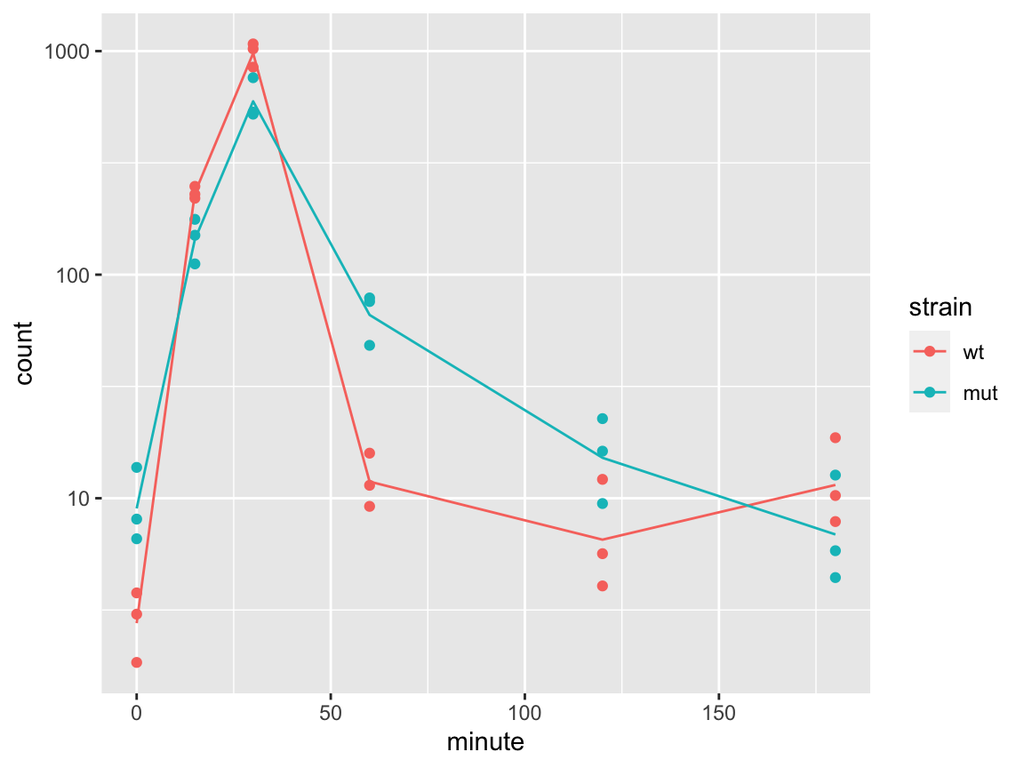

```r
fiss <- plotCounts(ddsTC, which.min(resTC$padj),
                   intgroup = c("minute","strain"), returnData = TRUE)
fiss$minute <- as.numeric(as.character(fiss$minute))
ggplot(fiss,
  aes(x = minute, y = count, color = strain, group = strain)) +
  geom_point() + stat_summary(fun.y=mean, geom="line") +
  scale_y_log10()
```

### Perform a wald test for the log2 fold changes at individual time points using the test argument in the function results()

```r
resultsNames(ddsTC)
```

```
##  [1] "Intercept"           "strain_mut_vs_wt"    "minute_15_vs_0"
##  [4] "minute_30_vs_0"      "minute_60_vs_0"      "minute_120_vs_0"
##  [7] "minute_180_vs_0"     "strainmut.minute15"  "strainmut.minute30"
## [10] "strainmut.minute60"  "strainmut.minute120" "strainmut.minute180"
```

```r
res30 <- results(ddsTC, name="strainmut.minute30", test="Wald")
res30[which.min(resTC$padj),]
```

```
## log2 fold change (MLE): strainmut.minute30
## Wald test p-value: strainmut.minute30
## DataFrame with 1 row and 6 columns
##                      baseMean    log2FoldChange             lfcSE
##                     <numeric>         <numeric>         <numeric>
## SPBC2F12.09c 174.671161802578 -2.60046902875453 0.634342916343005
##                           stat               pvalue              padj
##                      <numeric>            <numeric>         <numeric>
## SPBC2F12.09c -4.09946885471073 4.14099389595899e-05 0.279931187366828
```

```r
betas <- coef(ddsTC)
colnames(betas)
```

```
##  [1] "Intercept"           "strain_mut_vs_wt"    "minute_15_vs_0"
##  [4] "minute_30_vs_0"      "minute_60_vs_0"      "minute_120_vs_0"
##  [7] "minute_180_vs_0"     "strainmut.minute15"  "strainmut.minute30"
## [10] "strainmut.minute60"  "strainmut.minute120" "strainmut.minute180"
```

### Plot the log2 fold changes in a heatmap using the function pheatmap()

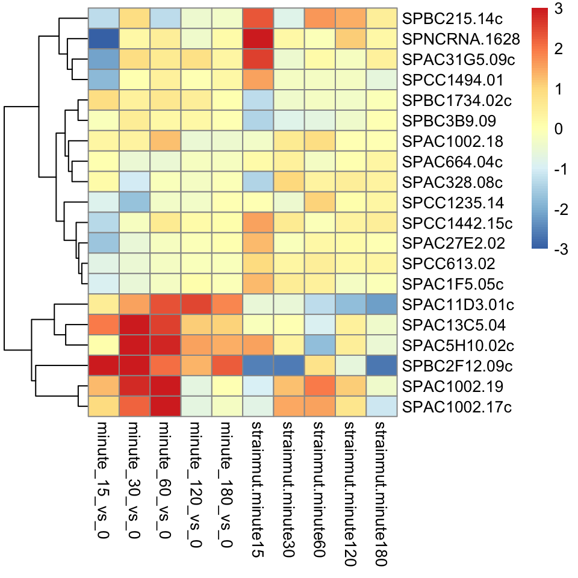

```r
topGenes <- head(order(resTC$padj),20)
mat <- betas[topGenes, -c(1,2)]
thr <- 3
mat[mat < -thr] <- -thr
mat[mat > thr] <- thr
pheatmap(mat, breaks=seq(from=-thr, to=thr, length=101),
         cluster_col=FALSE)
```